# Taller sintético: aprendizaje no supervisado (S5)

# 1. Introducción

- Sin etiquetas, el objetivo es **descubrir estructura**. Recorremos las **tres tareas** de la sesión sobre **una sola base**.
- Usamos el **cáncer de seno** (`wisc_bc_data.csv`): 30 medidas del núcleo celular de 569 biopsias. Ignoramos el diagnóstico al agrupar; lo usamos solo al final para validar.
- Cada tarea sale con **una función**: `kmeans()` (clustering), `lof()` (anomalías) y `prcomp()` (PCA).

# 2. Datos

```r
install.packages("dbscan")
```

- Único preprocesamiento: tomar las 30 medidas y **estandarizarlas** (para que ninguna domine por su escala):

```r
library(dbscan)
bc <- read.csv("data/wisc_bc_data.csv")
X  <- scale(bc[, 3:32])   # 30 variables numéricas (sin id ni diagnóstico)
dim(X)
```

```
## [1] 569  30
```

# 3. Clustering con k-medias

- `kmeans()` agrupa las biopsias en `k=2` grupos, **sin ver** el diagnóstico:

```r
set.seed(123)
km <- kmeans(X, centers = 2)
km$size
```

```
## [1] 194 375
```

- ¿Los grupos tienen sentido? Los cruzamos con el diagnóstico real (que no usamos para agrupar):

```r
table(cluster = km$cluster, diagnostico = bc$diagnosis)
```

```
##        diagnostico
## cluster   B   M
##       1  18 176
##       2 339  36
```

- Sin etiquetas, el clustering **recupera** en buena medida la separación benigno/maligno.

# 4. Detección de anomalías (LOF)

- `lof()` da a cada biopsia un puntaje: $\approx 1$ es normal, $\gg 1$ es atípico (vive en una zona poco densa):

```r
bc$lof <- lof(X, minPts = 20)
round(summary(bc$lof), 2)   # distribución de los puntajes
```

```
##    Min. 1st Qu.  Median    Mean 3rd Qu.    Max.
##    0.96    1.02    1.07    1.14    1.18    2.90
```

- Las 5 biopsias más atípicas:

```r
head(bc[order(-bc$lof), c("diagnosis", "radius_mean", "area_mean", "lof")], 5)
```

```
##     diagnosis radius_mean area_mean      lof
## 213         M      28.110    2499.0 2.895800
## 462         M      27.420    2501.0 2.519825
## 214         M      17.420     948.0 2.357405
## 153         B       9.731     300.2 2.346742
## 193         B       9.720     288.1 2.065701
```

# 5. PCA: representar y visualizar

- `prcomp()` resume las 30 variables en pocas componentes. Varianza de las primeras:

```r
pca <- prcomp(X)
round(summary(pca)$importance[, 1:5], 3)
```

```
##                          PC1   PC2   PC3   PC4   PC5
## Standard deviation     3.644 2.386 1.679 1.407 1.284
## Proportion of Variance 0.443 0.190 0.094 0.066 0.055
## Cumulative Proportion  0.443 0.632 0.726 0.792 0.847
```

- Proyectamos a 2 dimensiones y vemos **las tres cosas a la vez**: color = cluster, círculos negros = el 2% más atípico (LOF):

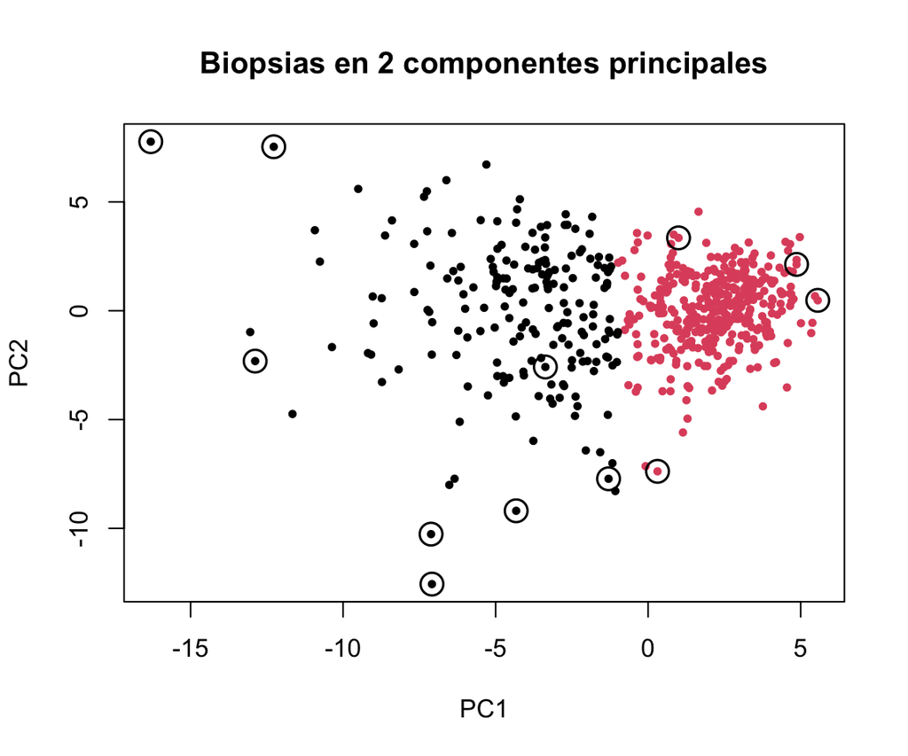

```r
anom <- bc$lof >= quantile(bc$lof, 0.98)
plot(pca$x[, 1:2], col = km$cluster, pch = 19, cex = 0.6,
     main = "Biopsias en 2 componentes principales", xlab = "PC1", ylab = "PC2")
points(pca$x[anom, 1:2], pch = 1, cex = 2, col = "black", lwd = 1.5)
```

# 6. Cierre

- Con **una sola base** vimos las tres caras del aprendizaje no supervisado:
  - **Clustering** (`kmeans`): agrupa sin etiquetas; aquí recupera casi benigno/maligno.
  - **Anomalías** (`lof`): marca los casos raros, sin etiquetas.
  - **PCA** (`prcomp`): resume 30 variables en 2 para visualizar (mostrando de paso los grupos y las anomalías).
- Todo con **una función** por tarea y **estandarizar** como único preprocesamiento.